# Visualizations from JAT dataset

Alice

3/16/2021

```r
merged <- readRDS('~/Documents/merged_jat.Rds')
od_clean <- readRDS('~/Documents/od_clean.Rds')
ddd <- readRDS('~/Documents/ddd.Rds')
```

# Questions from April 7 team meeting

1. There must be some sentencing guidelines. Do judges follow them or not? (Alice)
2. Trial duration (time between arrest and disposition) (Alice)
3. Were they waiting in jail? Did they post bail? (Alice)

I used the data I had already manipulated and saved locally in the ‘aw_process_data.R’ script.

## Do judges follow sentencing guidelines?

I selected some top statutes. [PA law sentencing guidelines](https://www.pacodeandbulletin.gov/Display/pacode?file=/secure/pacode/data/204/chapter303/chap303toc.html&d=reduce) are very complicated. So it would be a piece of future work to create some code that would take in the data from a docket and algorithmically produce the guideline. I am guessing judges already have that.

Then I selected an example judge and calculated the “typical” sentence by summarizing all the other judges. For a dashboard - we could pre-calculate all this information and then the input could be to select the judge and the offense.

### Most common statutes in the data

I decided to work with these common offenses as an illustration.

- M2 Simple Assault
- M2 Recklessly Endangering Another Person
- M Int Poss Contr Subst By Per Not Reg

```r
od_clean %>% count(grade, description_clean, sort=T) %>%
  head() %>% pander::pander()
```

| grade | description_clean | n |
| --- | --- | --- |
| M | Int Poss Contr Subst By Per Not Reg | 75564 |
| F | Manufacture, Delivery, or Possession With Intent to Manufacture or Deliver | 74533 |
| M2 | Simple Assault | 38684 |
| M2 | Recklessly Endangering Another Person | 33646 |
| M1 | Poss Instrument Of Crime W/Int | 30385 |
| F | Conspiracy | 25380 |

There are a couple of ways to work on the data

- Consider only offenses on a docket with a disposition (many rows from a docket do not have a disposition)
- Consider the docket holistically - if the offense occurs on the docket, but doesn’t have a disposition, still consider that as an occurence of the offense and look at the overall docket

For this purpose, I will try the first one - and look for only sentences specifically associated with that offense of interest. I could summarize the other offenses on the docket as a second variable to consider.

Note: This analysis does not include sentences with time served.

### Choose some judges for illustration

What are the most common judges for the selected offenses?

```r
od_clean %>%
  mutate(grade_desc = paste(grade,description_clean,sep="_")) %>%
  filter(grade_desc %in% c("M2_Simple Assault", "M2_Recklessly Endangering Another Person",
    "M_Int Poss Contr Subst By Per Not Reg")) %>%
  count(disposing_authority__document_name, sort=T) %>%
  head() %>% pander::pander()
```

| disposing_authority__document_name | n |
| --- | --- |
| NA | 77144 |
| Rayford A. Means | 3972 |
| Thomas F. Gehret | 3052 |
| Wendy L. Pew | 2551 |
| Robert P. Coleman | 2470 |
| Karen Y. Simmons | 2395 |

Based on this information, I used Rayford A. Means as the example.

```r
input_judge <- "Rayford A. Means"
od_filtered <- od_clean %>%
  mutate(grade_desc = paste(grade,description_clean,sep="_"),
         select_judge = disposing_authority__document_name==input_judge) %>%
  filter(grade_desc %in% c("M2_Simple Assault", "M2_Recklessly Endangering Another Person",
    "M_Int Poss Contr Subst By Per Not Reg"),
    !is.na(disposition))

sentence_type_summary <- od_filtered %>%
  group_by(grade_desc, select_judge) %>%
  count(sentence_type) %>%
  mutate(prop_sentence_type = n/sum(n)) %>%
  ungroup() %>%
  mutate(axis_label = paste0(sentence_type, " (n=", as.character(n), ")"))

sentence_length_summary <- od_filtered %>%
  group_by(grade_desc, select_judge, sentence_type) %>%
  summarise(median_min_days = median(min_period_days, na.rm = T),
            mean_min_days = mean(min_period_days, na.rm = T),
            median_max_days = median(max_period_days, na.rm = T),
            mean_max_days = mean(max_period_days, na.rm = T))
```

### Plot the sentence type by offense

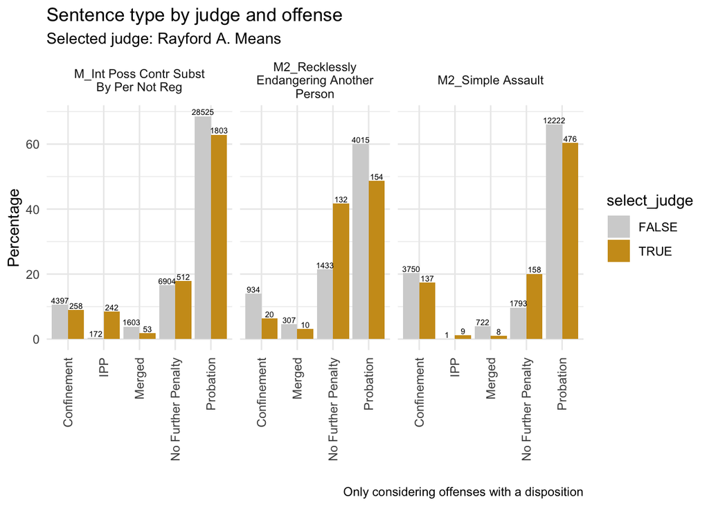

```r
ggplot(sentence_type_summary, aes(x=sentence_type,
                                  y = 100*prop_sentence_type,
                                  fill=select_judge)) +
  geom_bar(stat = "identity", position = "dodge") +
  geom_text(aes(label=n), size=2,
            position=position_dodge(width=0.9), vjust=-0.25) +
  facet_grid(.~grade_desc, scales = "free_x",space="free_x",
             labeller = labeller(grade_desc = label_wrap_gen(25)))+
  labs(title="Sentence type by judge and offense",
       subtitle = "Selected judge: Rayford A. Means",
       x = "", y = "Percentage",
       caption = "Only considering offenses with a disposition") +
  scale_fill_manual(values = c("lightgray","goldenrod3")) +
  theme_minimal() +
  theme(axis.text.x = element_text(angle=90, hjust=1,vjust=0.5))
```

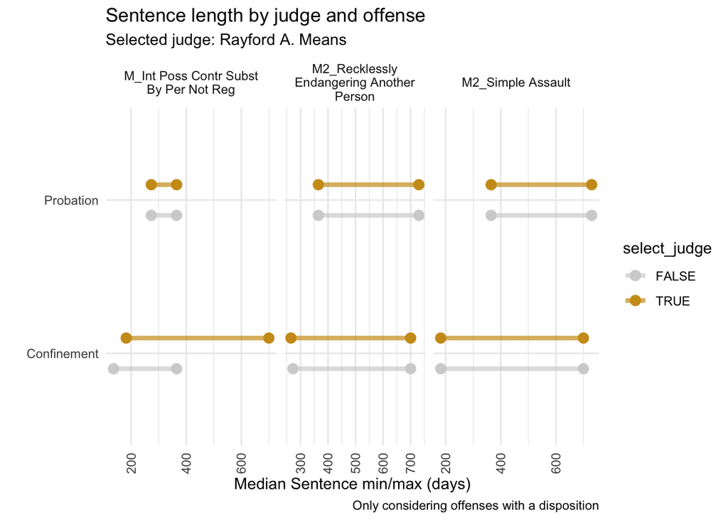

```r
sentence_length_summary %>%
  filter(sentence_type %in% c("Confinement","Probation")) %>%
  tidyr::pivot_longer(ends_with("days")) %>%
  filter(name %in% c("median_min_days","median_max_days")) %>%
  mutate(group = paste(select_judge,sentence_type)) %>%
  ggplot( aes(x=sentence_type,
              y = value,
              group = group,
              color=select_judge)) +
  geom_point(position = position_dodge(width=0.4), size = 3) +
  geom_line(position = position_dodge(width=0.4),
            size=1.5, alpha=0.7) +
  facet_grid(.~grade_desc, scales = "free_x",space="free_x",
             drop=T,
             labeller = labeller(grade_desc = label_wrap_gen(25)))+
  labs(title="Sentence length by judge and offense",
       subtitle = "Selected judge: Rayford A. Means",
       x = "", y = "Median Sentence min/max (days)",
       caption = "Only considering offenses with a disposition") +
  scale_color_manual(values = c("lightgray","goldenrod3")) +
  coord_flip() +
  theme_minimal() +
  theme(axis.text.x = element_text(angle=90, hjust=1,vjust=0.5))
```

# What was the wait until disposition? (time between arrest and disposition) (Alice)

For illustration, I will use the same example set of offenses and judge. (Eventually need to pre-calculate the summary stats for all judges and offenses?)

```r
process_duration_summary <- od_filtered %>%
  ungroup() %>%
  # Merge in ddd data
  left_join(ddd, by = "docket_id") %>%
  # group some variables
  mutate(disposition = forcats::fct_lump(disposition, n=4),
         disposition_method = forcats::fct_lump(disposition_method, n=4)) %>%
  group_by(grade_desc, select_judge, disposition_method) %>%
  summarise(n = n(),
            median_arrest_to_disp_days =
              median(as.double(difftime(disposition_date, arrest_date, units = "days")),
                     na.rm = T),
            mean_arrest_to_disp_days =
              mean(as.double(difftime(disposition_date, arrest_date, units = "days")),
                   na.rm = T),
            .groups = "drop") %>% ungroup()
```

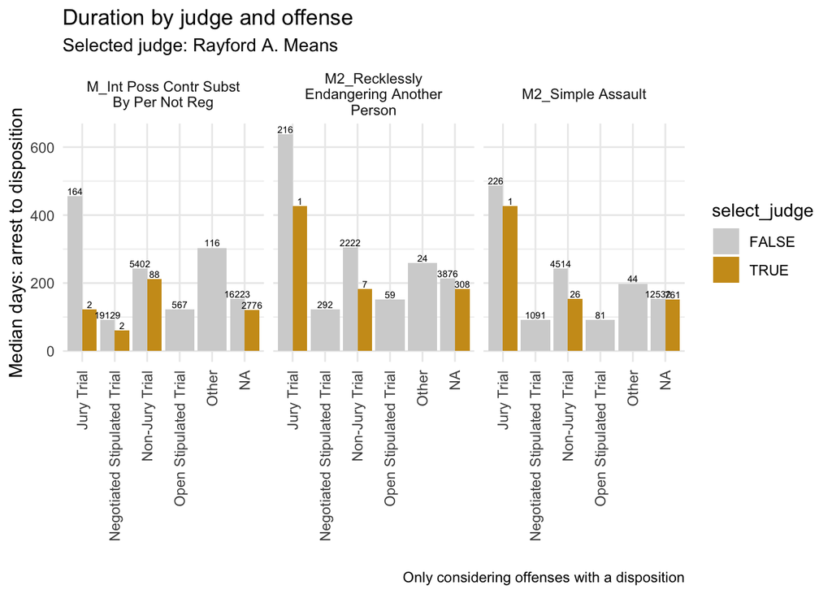

```r
process_duration_summary %>%
ggplot(aes(x=disposition_method,
                                  y = median_arrest_to_disp_days,
                                  fill=select_judge)) +
  geom_bar(stat = "identity", position = "dodge") +
  geom_text(aes(label=n), size=2,
            position=position_dodge(width=0.9), vjust=-0.25) +
  facet_grid(.~grade_desc, scales = "free_x",space="free_x",
             labeller = labeller(grade_desc = label_wrap_gen(25)))+
  labs(title="Duration by judge and offense",
       subtitle = "Selected judge: Rayford A. Means",
       x = "", y = "Median days: arrest to disposition",
       caption = "Only considering offenses with a disposition") +
  scale_fill_manual(values = c("lightgray","goldenrod3")) +
  theme_minimal() +
  theme(axis.text.x = element_text(angle=90, hjust=1,vjust=0.5))
```

# Past ideas

This is just a stream of consciousness exploration of the data and debugging all the data manipulations.

## Judge scorecard/summary

Can we filter by judge, then show some dashboard about them with comparisons “other judges”.

In the end, we could have some sort of judge search.

You select 1 judge and then can filter by:

- Offense (either high level by statute or search a specific term like “retail theft”)
- Defendant demographics
- Time period

We return:

- Number of dockets
- Sentence information
- Social media or news about the judge?

Top 2 judges by year (number of dockets)

```r
merged %>%
  mutate(year = lubridate::year(filing_date)) %>%
  group_by(year) %>%
  mutate(judge = forcats::fct_lump_n(judge, n=2))%>%
  ungroup() %>%
  filter(judge!="Other") %>%
  count(year,judge, sort=F) %>%
  pander::pander()
```

| year | judge | n |
| --- | --- | --- |
| 2010 | Rayford A. Means | 3320 |
| 2010 | Thomas F. Gehret | 1960 |
| 2011 | Rayford A. Means | 2397 |
| 2011 | Gerard A. Kosinski | 1145 |
| 2012 | Rayford A. Means | 2808 |
| 2012 | Gerard A. Kosinski | 836 |
| 2013 | Rayford A. Means | 2744 |
| 2013 | Donna Woelpper | 1432 |
| 2014 | Rayford A. Means | 2503 |
| 2014 | Harold M. Kane | 979 |
| 2015 | Rayford A. Means | 1728 |
| 2015 | Robert P. Coleman | 1415 |
| 2016 | Rayford A. Means | 1339 |
| 2016 | The Honorable Scott DiClaudio | 1933 |
| 2017 | Robert P. Coleman | 1433 |
| 2017 | The Honorable Scott DiClaudio | 1929 |
| 2018 | Robert P. Coleman | 1181 |
| 2018 | The Honorable Scott DiClaudio | 1018 |
| 2019 | Rayford A. Means | 661 |
| 2019 | Robert P. Coleman | 817 |
| 2020 | Rayford A. Means | 29 |
| 2020 | Robert P. Coleman | 36 |

Let’s take [Rayford A. Means](https://ballotpedia.org/Rayford_A._Means) as an example.

This [article](https://digital.olivesoftware.com/Olive/ODN/PhiladelphiaInquirer/shared/ShowArticle.aspx?doc=PHQP%2F2019%2F10%2F27&entity=Ar01701&sk=614449E1&mode=text#) claims that he was sentencing for longer than other judges for retail theft.

Take the case of “retail theft” - there are mutliple descriptions with some sort of retail theft. These could vary a lot, but for now, take anything with “retail theft” in it. Lots of these dockets contain other crimes that might be much more severe. A quick check says that there are some felonies.

```r
input <- list()
input$judge <- "Rayford A. Means"
input$statute_title <- NULL
input$grade <- NULL
input$minyear <- 2010
input$maxyear <- 2020
input$search_term <- "retail theft"
input$defendant_age <- NULL
input$defendant_gender <- "Male"
input$defendant_race <- NULL
```

Summarize the search:

```r
input %>% as.data.frame() %>% pander::pander()
```

| judge | minyear | maxyear | search_term | defendant_gender |
| --- | --- | --- | --- | --- |
| Rayford A. Means | 2010 | 2020 | retail theft | Male |

```r
# Have not implemented all the searches, just a couple of them to illustrate
if(is.null(input$search_term)) input$search_term <- "*"
if(is.null(input$statute_title)) input$statute_title <- unique(unlist(merged$statute_title))


# Modify the data based on these searches
mydata <- merged %>%
  mutate(year = lubridate::year(filing_date),
         select_judge = ifelse(judge==input$judge, T, F),
         max_sentence_all = pmax(max_period_days_Probation,max_period_days_Confinement,
                                 na.rm = T)
  )

# this is too slow
mydata$select_searchterm <- tolower(mydata$description_clean) %>%
  grepl(pattern = tolower(input$search_term), unlist(.))

# Filter the data based on these searches

mydata <- mydata %>%
  filter(gender == input$defendant_gender,
         select_searchterm,
         year >= input$minyear & year <= input$maxyear,
         any(statute_title %in% input$statute_title))
```

### Total dockets per year

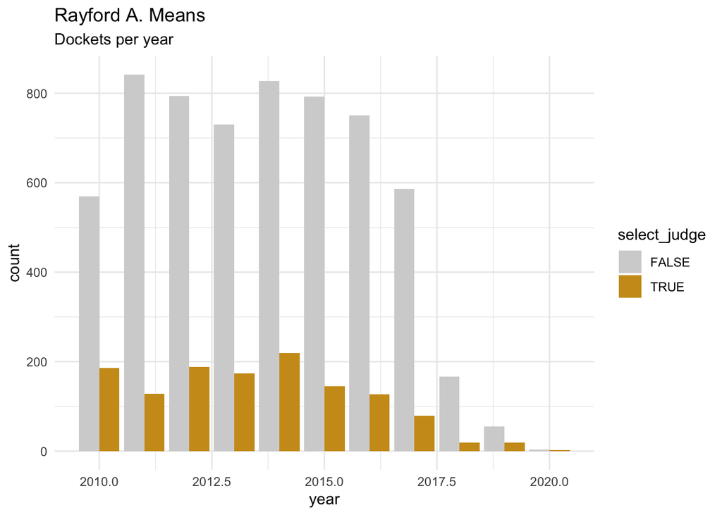

```r
mydata %>%
  ggplot(aes(x=year,fill=select_judge)) +
  geom_bar(position = "dodge") +
  labs(title=input$judge,
       subtitle = "Dockets per year") +
  scale_fill_manual(values = c("lightgray","goldenrod3")) +
  theme_minimal()
```

### Total dockets by max grade of any offense on that docket

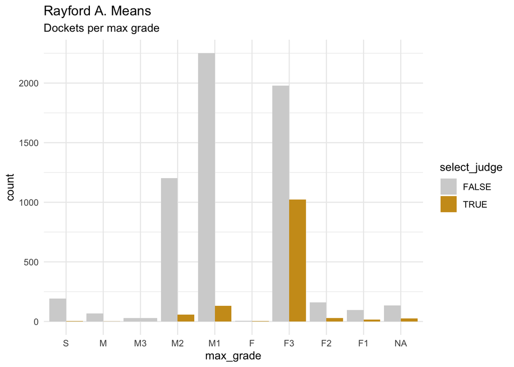

```r
mydata %>%
  ggplot(aes(x=max_grade,fill=select_judge)) +
  geom_bar(position = "dodge") +
  labs(title=input$judge,
       subtitle = "Dockets per max grade") +
  scale_fill_manual(values = c("lightgray","goldenrod3")) +
  theme_minimal()
```

### Demographics of defendants

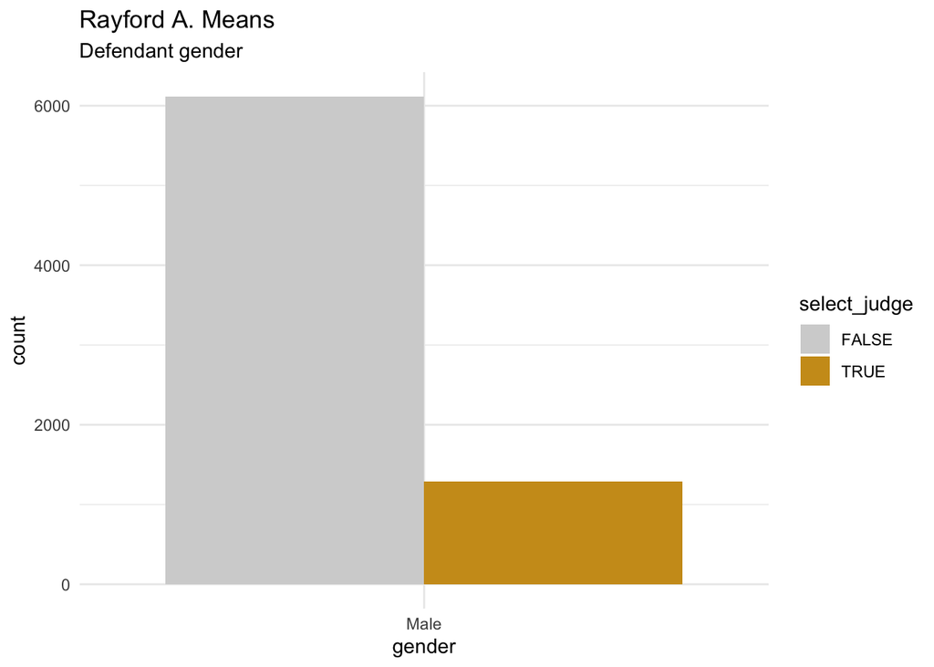

```r
mydata %>%
  ggplot(aes(x=gender,fill=select_judge)) +
  geom_bar(position = "dodge") +
  labs(title=input$judge,
       subtitle = "Defendant gender") +

  scale_fill_manual(values = c("lightgray","goldenrod3")) +
  theme_minimal()
```

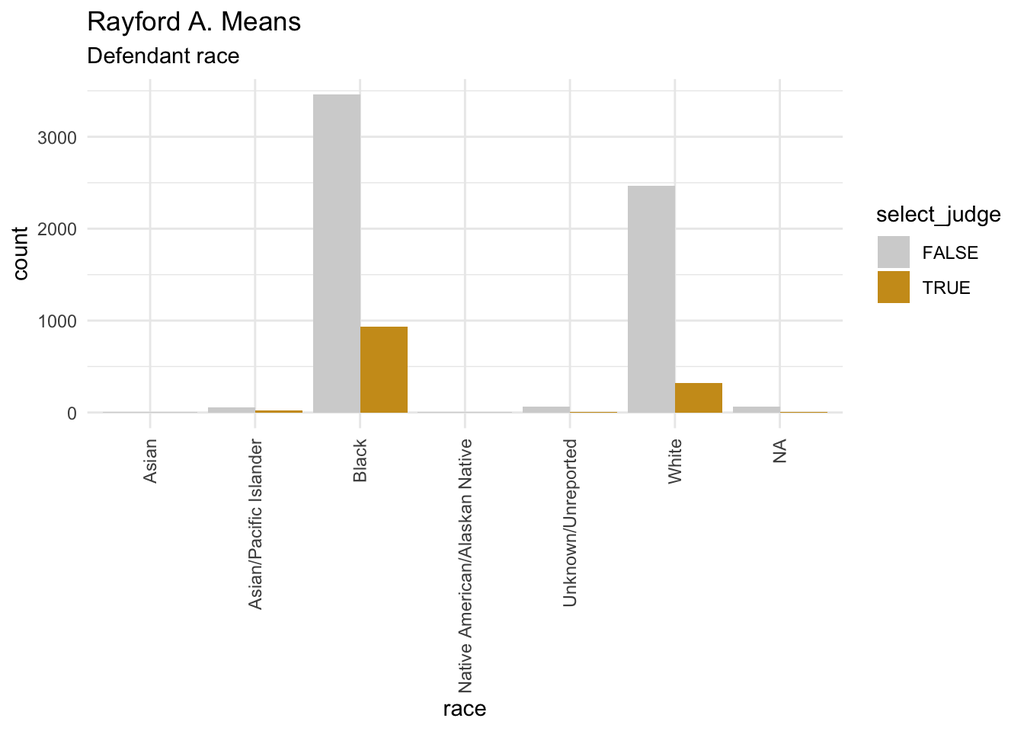

```r
mydata %>%
  ggplot(aes(x=race,fill=select_judge)) +
  geom_bar(position = "dodge") +
  labs(title=input$judge,
       subtitle = "Defendant race") +

  scale_fill_manual(values = c("lightgray","goldenrod3")) +
  theme_minimal() +
  theme(axis.text.x = element_text(angle =90, hjust=1,vjust=0.5))
```

### Dispositions

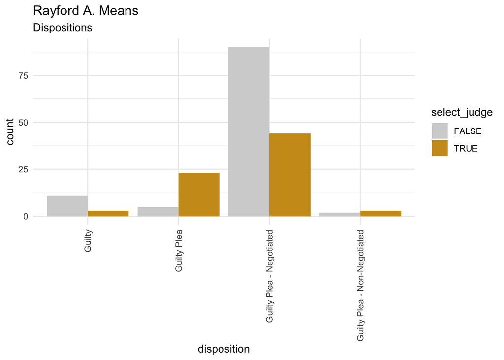

```r
mydata %>%
  tidyr::unnest(disposition) %>%
  na.omit() %>%
  ggplot(aes(x=disposition,fill=select_judge)) +
  geom_bar(position = "dodge") +
  labs(title=input$judge,
       subtitle = "Dispositions") +

  scale_fill_manual(values = c("lightgray","goldenrod3")) +
  theme_minimal() +
  theme(axis.text.x = element_text(angle =90, hjust=1,vjust=0.5))
```

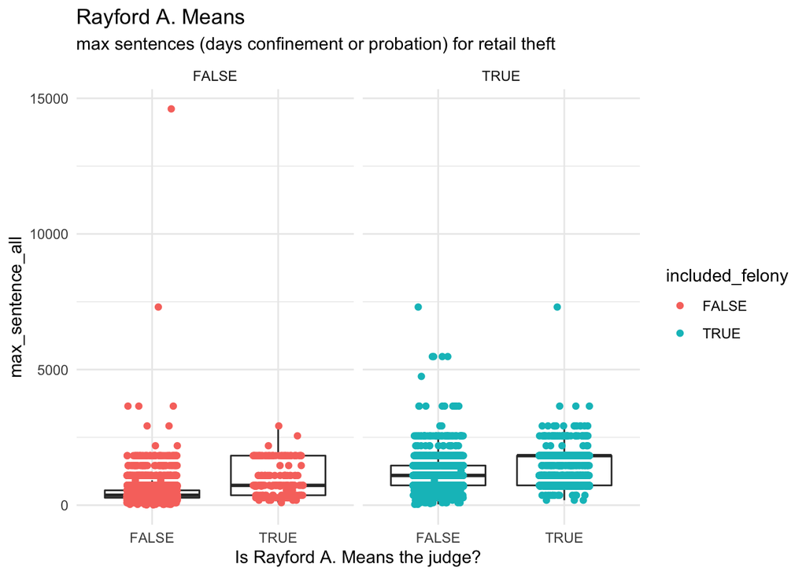

```r
mydata %>%
  mutate(included_felony = ifelse(max_grade %in% c("F","F1","F2","F3"), T, F)) %>%
  ggplot(aes(x=select_judge, group= select_judge, y= max_sentence_all)) +
  geom_boxplot(outlier.shape = NA) +
  geom_jitter(height=0,width=0.2, aes(color = included_felony)) +
  facet_wrap(~included_felony) +
  # scale_y_log10() +
  labs(title=input$judge,
       x = "Is Rayford A. Means the judge?",
       subtitle = "max sentences (days confinement or probation) for retail theft") +

  scale_fill_manual(values = c("lightgray","goldenrod3")) +
  theme_minimal()
```

### Bail

Note that the judges for bail are different than the judges for dispositions! I did not get very far here.

R version 3.6.2 (2019-12-12) Platform: x86_64-apple-darwin15.6.0 (64-bit) Running under: macOS 10.16

Matrix products: default BLAS: /Library/Frameworks/R.framework/Versions/3.6/Resources/lib/libRblas.0.dylib LAPACK: /Library/Frameworks/R.framework/Versions/3.6/Resources/lib/libRlapack.dylib

locale: [1] en_US.UTF-8/en_US.UTF-8/en_US.UTF-8/C/en_US.UTF-8/en_US.UTF-8

attached base packages: [1] stats graphics grDevices utils datasets methods base

other attached packages: [1] dplyr_1.0.2 viridis_0.5.1 viridisLite_0.3.0 ggplot2_3.3.3